# Time-Series with stock prices

Visualizing stock prices of one Finnish company which stock are quoted in Helsinki Stock Exchange. Idea is to visualize time-serie data in understandable form, create few known indicators, and present the result.

- Daily end price
- Daily exchange volumes
- Bollinger bands
- Volatility

#### Importing relevant libraries

- Numpy for numerical Python operations.
- Pandas for dataframes.
- Seaborn to visualize the data.

```python
import numpy as np
import pandas as pd
import seaborn as sns
import matplotlib.pyplot as plt
```

#### Data exploration

We are using data of one Finnish company daily stock prices. Let's take a look at the data and how does it look like.

```python
# Load the xls data file
df = pd.read_excel('osakedata.xls')
# Checking the first rows to see how's the data
df.head()
```

|  | Päivämäärä | Ylin | Alin | Päätöskurssi | Keskimäärin | Muutos % | Vaihto kpl | Vaihto € |
| --- | --- | --- | --- | --- | --- | --- | --- | --- |
| 0 | 2019-05-22 03:00:00 | 33.85 | 32.1 | 33.65 | 33.447872 | 2.27964 | 14209 | 475886.35 |
| 1 | 2019-05-21 03:00:00 | 33.45 | 32.0 | 32.90 | 32.928947 | 1.85759 | 61415 | 2029115.90 |
| 2 | 2019-05-20 03:00:00 | 33.50 | 32.0 | 32.30 | 33.057231 | -1.67428 | 1223 | 40418.90 |
| 3 | 2019-05-17 03:00:00 | 33.40 | 32.5 | 32.85 | 33.017594 | -1.05422 | 3970 | 131079.85 |
| 4 | 2019-05-16 03:00:00 | 33.20 | 32.5 | 33.20 | 32.785128 | 1.37405 | 780 | 25572.40 |

Looks quite neat already but we'll tidy it a bit in a while for at least:

- Use the date as row index
- Translate columns to English
- Delete columns we don't need

As we now see how the data looks we can check if there's any missing data.

```python
df.isnull().sum()
```

```
Päivämäärä      0
Ylin            0
Alin            0
Päätöskurssi    0
Keskimäärin     0
Muutos %        0
Vaihto kpl      0
Vaihto €        0
dtype: int64
```

No missing data so no need for missing data handling. Next we can make the transformations to data as proposed earlier.

```python
# Changing column names
df = df.rename(columns={'Päivämäärä':'Date', 'Ylin':'High', 'Alin':'Low', 'Päätöskurssi':'Close', 'Vaihto kpl':'Vol qty', 'Vaihto €':'Vol eur'})
# Setting the date as row index
df.set_index('Date', inplace=True)
# Deleting columns we don't need
df = df.drop(columns=['Keskimäärin','Muutos %'])
# Checking the result
df.head()
```

| Date | High | Low | Close | Vol qty | Vol eur |
| --- | --- | --- | --- | --- | --- |
| 2019-05-22 03:00:00 | 33.85 | 32.1 | 33.65 | 14209 | 475886.35 |
| 2019-05-21 03:00:00 | 33.45 | 32.0 | 32.90 | 61415 | 2029115.90 |
| 2019-05-20 03:00:00 | 33.50 | 32.0 | 32.30 | 1223 | 40418.90 |
| 2019-05-17 03:00:00 | 33.40 | 32.5 | 32.85 | 3970 | 131079.85 |
| 2019-05-16 03:00:00 | 33.20 | 32.5 | 33.20 | 780 | 25572.40 |

```python
# Let's sort the index to order the date in ascending order for the visualizatino purposes
df = df.sort_index()
```

```python
df.head()
```

| Date | High | Low | Close | Vol qty | Vol eur |
| --- | --- | --- | --- | --- | --- |
| 2018-03-20 02:00:00 | 28.5 | 28.1 | 28.3 | 1507 | 42659.8 |
| 2018-03-21 02:00:00 | 28.5 | 28.3 | 28.4 | 1102 | 31235.6 |
| 2018-03-22 02:00:00 | 28.5 | 28.0 | 28.0 | 2666 | 75118.5 |
| 2018-03-23 02:00:00 | 28.5 | 28.0 | 28.3 | 1669 | 47111.9 |
| 2018-03-26 03:00:00 | 28.3 | 28.0 | 28.0 | 2725 | 76786.8 |

```python
# Checking the data types of columns.
df.dtypes
```

```
High       float64
Low        float64
Close      float64
Vol qty      int64
Vol eur    float64
dtype: object
```

Everything looks quite ok now and: data types looks good, no missing values.

#### Creating more indicators from data

We'll create several new indicators as follows:

- 20-day moving average
- standard deviation
- bollinger bands

```python
df["20_moving"] = df["Close"].rolling(window=20).mean()
std_dev = df["Close"].rolling(window=20).std()
df["bol_lo"] = df["Close"].rolling(window=20).mean() - (2*std_dev)
df["bol_hi"] = df["Close"].rolling(window=20).mean() + (2*std_dev)
```

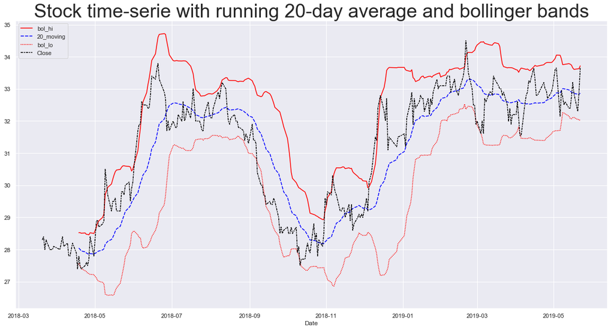

```python
sns.set(style="darkgrid")
plt.figure(figsize=(20,10))
#plt.figure.suptitle('Stock ', fontsize=16)
plt.title('Stock time-serie with running 20-day average and bollinger bands', fontdict={'fontsize': 36})
ax = sns.lineplot(data=df[['bol_hi', '20_moving', 'bol_lo', 'Close']], palette=['red', 'blue', 'red', 'black'])
```